# SIG16 ATAC: DESeq2 QC (merged replicates, IDR 0.05 peak atlas)

EYW

2026-09-26

```r
suppressPackageStartupMessages({
  library(tidyverse)
  library(DESeq2)
  library(pheatmap)
  library(RColorBrewer)
  library(ggrepel)
})
knitr::opts_chunk$set(echo = TRUE)

source("../../functions/r_custom/plotting_fxns.R")
theme_set(theme_Publication())

set.seed(1)
options(ggrepel.max.overlaps = Inf)

idr <- 0.05
job.name <- paste0("idr-", idr, "/")

OUT_DIR  <- file.path("../../analysis_outs", "deseq2-merged-reps", job.name)
PLOT_DIR <- file.path("../../analysis_outs", "plots_new", "deseq2-merged-reps", job.name)
dir.create(OUT_DIR, recursive = TRUE, showWarnings = FALSE)
dir.create(PLOT_DIR, recursive = TRUE, showWarnings = FALSE)
```

# Goal

Rebuild the DESeq2 object for the SIG16 bulk ATAC screen (naive CD4 T cells stimulated with `ligand1` in {none, IL4, IL6, TGFb} crossed with `ligand2` in {none, TNF}, 3 mice) over the IDR 0.05 consensus peak atlas, and reproduce the QC panels from the external collaborator’s `ATAC-analysis/SIG16_ATAC/1-deseq.R`.

The design is `~ mouse + ligand1 + ligand2 + ligand1:ligand2`, so the model carries a per-mouse blocking term, the two single-ligand main effects, and the interaction term that the downstream synergy/antagonism calls are built on.

# Import

`counts_mat.rds` is the `Rsubread::featureCounts` output over the peak atlas; `annotation.tsv` is the ChIPseeker annotation of the same atlas (peak -> nearest gene / distance to TSS).

```r
counts_mat <- readRDS(file.path(OUT_DIR, "counts_mat.rds"))
count.matrix <- counts_mat$counts

annot <- read.csv(file.path("../../analysis_outs/chipseeker", job.name,
                            "all.peakatlas/annotation.tsv"), sep = "\t")

# Condition / ligand colors come from the RColorBrewer "Paired" palette: each ligand1
# gets one light/dark pair, light = ligand2 none, dark = ligand2 TNF. Written back to
# `plots/palette.rds`, which is what 02_/03_/04_ read.
paired <- brewer.pal(12, "Paired")
names(paired) <- c("lt.blue", "blue", "lt.green", "green", "lt.red", "red",
                   "lt.orange", "orange", "lt.purple", "purple", "lt.brown", "brown")

pal <- list(
  condition = c(
    none_none = unname(paired["lt.purple"]),
    none_TNF  = unname(paired["purple"]),
    IL4_none  = unname(paired["lt.blue"]),
    IL4_TNF   = unname(paired["blue"]),
    IL6_none  = unname(paired["lt.green"]),
    IL6_TNF   = unname(paired["green"]),
    TGFb_none = unname(paired["lt.red"]),
    TGFb_TNF  = unname(paired["red"])
  ),
  ligand1 = c(
    none = unname(paired["purple"]),
    IL4  = unname(paired["blue"]),
    IL6  = unname(paired["green"]),
    TGFb = unname(paired["red"])
  ),
  ligand2 = c(
    none = unname(paired["lt.orange"]),
    TNF  = unname(paired["orange"])
  ),
  rep = c(`1` = unname(paired["blue"]),
          `2` = unname(paired["green"]),
          `3` = unname(paired["red"]))
)
saveRDS(pal, "../../analysis_outs/plots/palette.rds")

dim(count.matrix)
```

```
## [1] 63218    24
```

```r
colSums(count.matrix)
```

```
##  IL4_none_1  IL4_none_2  IL4_none_3   IL4_TNF_1   IL4_TNF_2   IL4_TNF_3
##     9039866     9225407    11194604    11031442     9426597     7023348
##  IL6_none_1  IL6_none_2  IL6_none_3   IL6_TNF_1   IL6_TNF_2   IL6_TNF_3
##     8606576    10131322    12001900    10416415    13319981    15625362
## none_none_1 none_none_2 none_none_3  none_TNF_1  none_TNF_2  none_TNF_3
##    15011113    14865416    13645632    10086366    12132433    13717405
## TGFb_none_1 TGFb_none_2 TGFb_none_3  TGFb_TNF_1  TGFb_TNF_2  TGFb_TNF_3
##    14366062    16154296    16761064     7505278    16313487    14867033
```

# Sample metadata

Sample names encode `{ligand1}_{ligand2}_{rep}`; replicate index is also the mouse of origin.

```r
condition <- factor(str_split_i(colnames(count.matrix), "_[1-3]", i = 1),
                    levels = c("none_none", "none_TNF", "IL4_none", "IL4_TNF",
                               "IL6_none", "IL6_TNF", "TGFb_none", "TGFb_TNF"))
ligand1 <- factor(str_split_i(colnames(count.matrix), "_", i = 1),
                  levels = c("none", "IL4", "IL6", "TGFb"))
ligand2 <- factor(str_split_i(colnames(count.matrix), "_", i = 2),
                  levels = c("none", "TNF"))
rep   <- factor(str_split_i(colnames(count.matrix), "_", i = 3))
mouse <- factor(rep(c(1, 2, 3), 8), levels = c(1, 2, 3))

metadata <- data.frame(condition = condition, ligand1 = ligand1, ligand2 = ligand2,
                       rep = rep, mouse = mouse)
rownames(metadata) <- colnames(count.matrix)
metadata
```

```
##             condition ligand1 ligand2 rep mouse
## IL4_none_1   IL4_none     IL4    none   1     1
## IL4_none_2   IL4_none     IL4    none   2     2
## IL4_none_3   IL4_none     IL4    none   3     3
## IL4_TNF_1     IL4_TNF     IL4     TNF   1     1
## IL4_TNF_2     IL4_TNF     IL4     TNF   2     2
## IL4_TNF_3     IL4_TNF     IL4     TNF   3     3
## IL6_none_1   IL6_none     IL6    none   1     1
## IL6_none_2   IL6_none     IL6    none   2     2
## IL6_none_3   IL6_none     IL6    none   3     3
## IL6_TNF_1     IL6_TNF     IL6     TNF   1     1
## IL6_TNF_2     IL6_TNF     IL6     TNF   2     2
## IL6_TNF_3     IL6_TNF     IL6     TNF   3     3
## none_none_1 none_none    none    none   1     1
## none_none_2 none_none    none    none   2     2
## none_none_3 none_none    none    none   3     3
## none_TNF_1   none_TNF    none     TNF   1     1
## none_TNF_2   none_TNF    none     TNF   2     2
## none_TNF_3   none_TNF    none     TNF   3     3
## TGFb_none_1 TGFb_none    TGFb    none   1     1
## TGFb_none_2 TGFb_none    TGFb    none   2     2
## TGFb_none_3 TGFb_none    TGFb    none   3     3
## TGFb_TNF_1   TGFb_TNF    TGFb     TNF   1     1
## TGFb_TNF_2   TGFb_TNF    TGFb     TNF   2     2
## TGFb_TNF_3   TGFb_TNF    TGFb     TNF   3     3
```

# FRiP

Fraction of reads in peaks, taken from the `featureCounts` assignment summary.

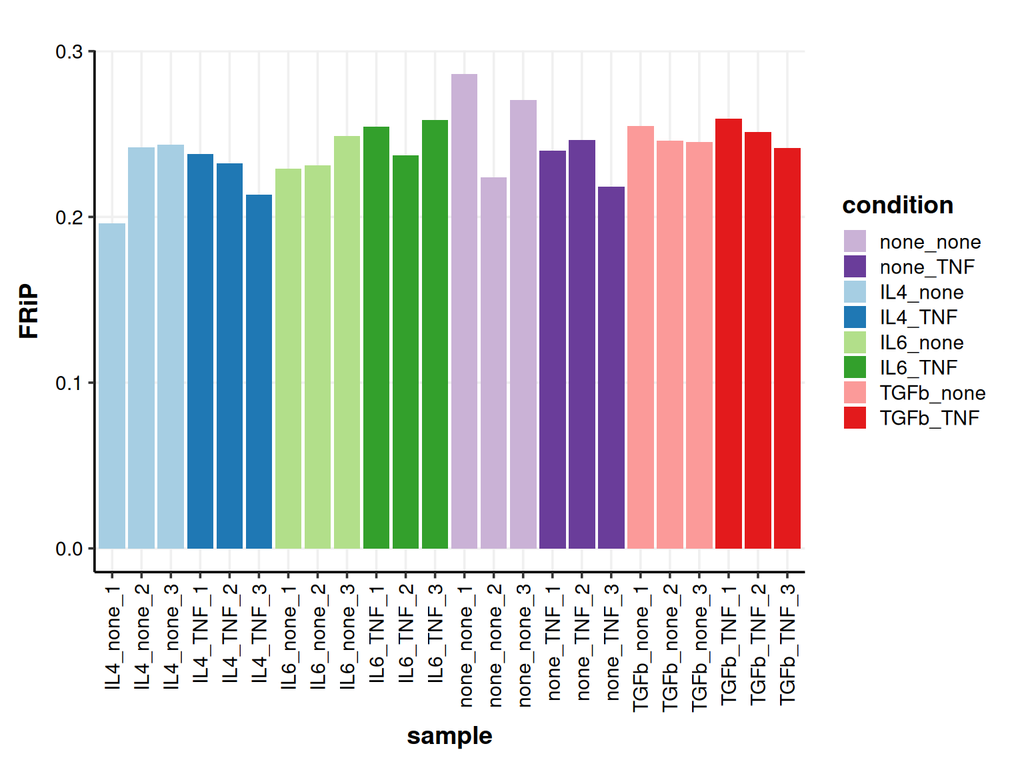

```r
FRiP_scores_atlas <- apply(counts_mat$stat[, !colnames(counts_mat$stat) %in% c("Status")],
                           2, function(sample) sample[1] / sum(sample))
FRiP_scores_atlas.df <- data.frame(sample = colnames(count.matrix),
                                   FRiP = FRiP_scores_atlas,
                                   condition = condition)

frip.p <- ggplot(FRiP_scores_atlas.df) +
  geom_bar(aes(x = sample, y = FRiP, fill = condition), stat = "identity") +
  scale_fill_manual(values = pal$condition) +
  theme(axis.text.x = element_text(angle = 90, vjust = 0.5, hjust = 1))
frip.p
```

```r
ggsave(file.path("../../analysis_outs/plots_new", paste0("bar-FRiP-idr-", idr, ".pdf")),
       frip.p, width = 8, height = 6)
```

# Fit DESeq2

Set `refit <- TRUE` to re-run `DESeq()` (a few minutes over ~63k peaks); otherwise the stored fit is loaded.

```r
refit <- FALSE

if (refit) {
  dds <- DESeqDataSetFromMatrix(count.matrix, colData = metadata,
                                design = ~ mouse + ligand1 + ligand2 + ligand1:ligand2)
  dds <- DESeq(dds)

  saveRDS(dds, file.path(OUT_DIR, "deseq2_dataset.rds"))
  saveRDS(metadata, file.path(OUT_DIR, "metadata.rds"))
  write.csv(metadata, file.path(OUT_DIR, "metadata.csv"), quote = FALSE)

  # VST matrix with the ChIPseeker annotation columns (distance to TSS / nearest gene)
  # pasted on, keyed by peak ID. Row order and rownames follow the DESeq2 object.
  normalized_counts <- vst(dds, blind = FALSE) %>%
    assay() %>%
    as.data.frame() %>%
    rownames_to_column("peak") %>%
    left_join(annot %>% dplyr::select(peak = name, distanceToTSS, geneSymbol),
              by = "peak") %>%
    column_to_rownames("peak")
  saveRDS(normalized_counts, file.path(OUT_DIR, "normalized_counts.rds"))
} else {
  dds <- readRDS(file.path(OUT_DIR, "deseq2_dataset.rds"))
  metadata <- readRDS(file.path(OUT_DIR, "metadata.rds"))
  normalized_counts <- readRDS(file.path(OUT_DIR, "normalized_counts.rds"))
}

resultsNames(dds)
```

```
##  [1] "Intercept"              "mouse_2_vs_1"           "mouse_3_vs_1"
##  [4] "ligand1_IL4_vs_none"    "ligand1_IL6_vs_none"    "ligand1_TGFb_vs_none"
##  [7] "ligand2_TNF_vs_none"    "ligand1IL4.ligand2TNF"  "ligand1IL6.ligand2TNF"
## [10] "ligand1TGFb.ligand2TNF"
```

Peaks that are zero in every sample (should be none, the atlas is built from called peaks):

```r
sum(rowSums(normalized_counts[, rownames(metadata)] == 0) == nrow(metadata))
```

```
## [1] 0
```

# Dispersion

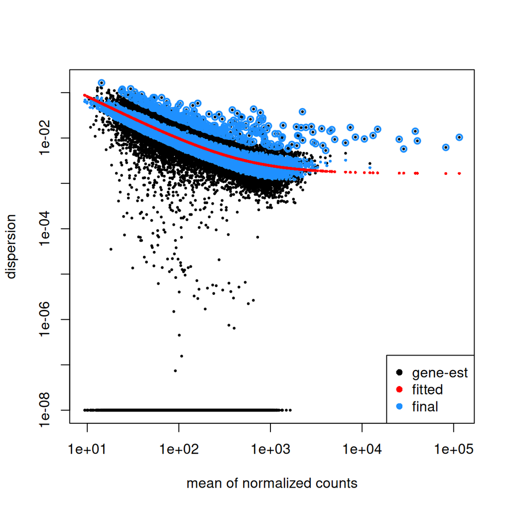

```r
plotDispEsts(dds)
```

```r
pdf(file.path(PLOT_DIR, "dispersion.pdf"))
plotDispEsts(dds)
invisible(dev.off())
```

# PCA

VST on the top 20% most variable peaks, `blind = FALSE` so the design is respected.

```r
vsd <- vst(dds, blind = FALSE)
vsd.mat <- assay(vsd)

pcaData <- plotPCA(vsd, intgroup = "condition", returnData = TRUE,
                   ntop = round(0.2 * nrow(vsd)))
```

```
## using ntop=12644 top features by variance
```

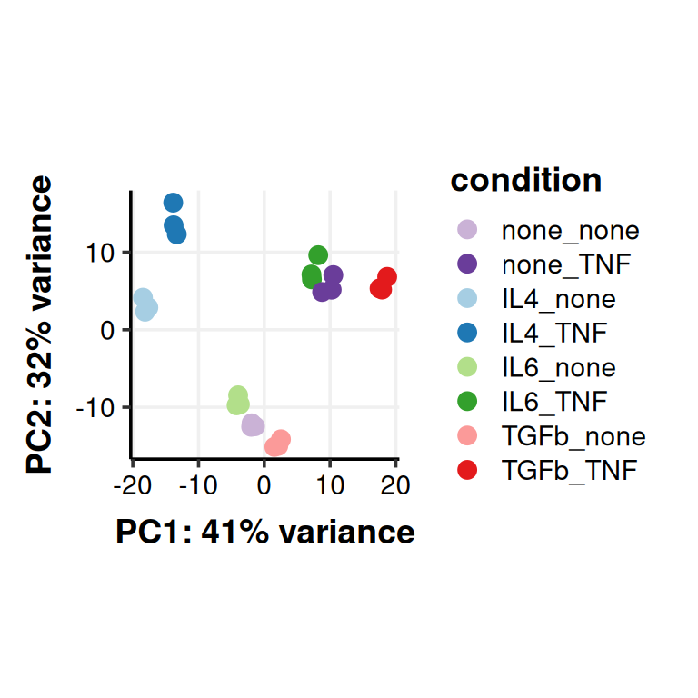

```r
percentVar <- round(100 * attr(pcaData, "percentVar"))
pcaData$sample <- pcaData$name

pca.p <- ggplot(pcaData, aes(PC1, PC2, color = condition, label = sample)) +
  geom_point(size = 3) +
  scale_color_manual(values = pal$condition) +
  xlab(paste0("PC1: ", percentVar[1], "% variance")) +
  ylab(paste0("PC2: ", percentVar[2], "% variance")) +
  theme(aspect.ratio = 1)
pca.p
```

```r
ggsave(file.path(PLOT_DIR, "pca-name.pdf"), pca.p)
```

# Sample-sample correlation

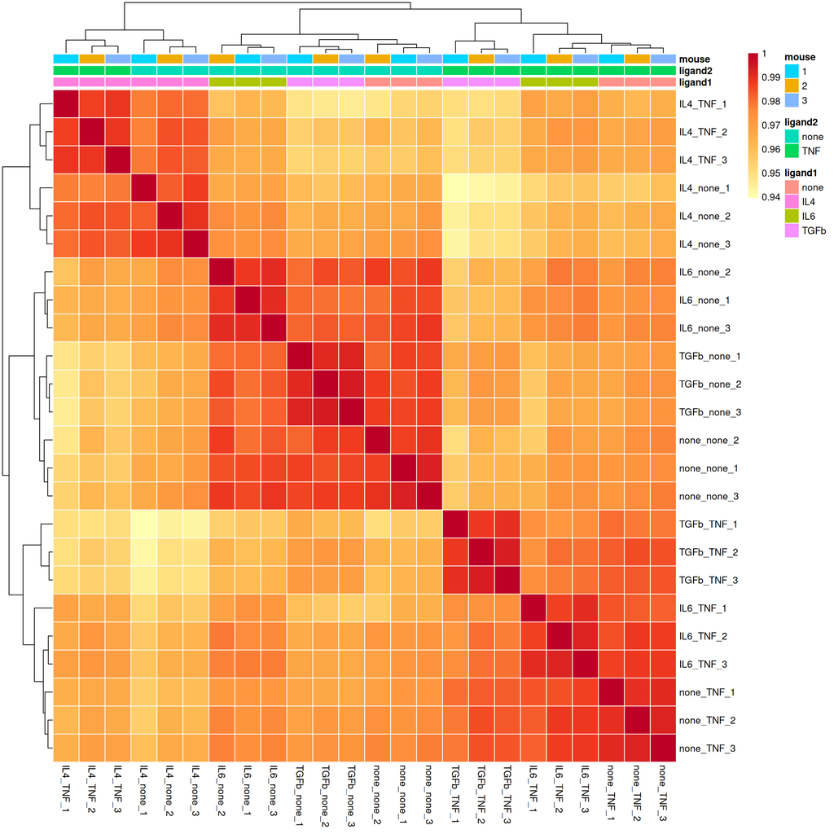

```r
vsd.cor <- cor(vsd.mat)
heat.colors <- colorRampPalette(brewer.pal(6, "YlOrRd"))(100)

cor.p <- pheatmap::pheatmap(vsd.cor,
                            annotation = metadata[, c("ligand1", "ligand2", "mouse")],
                            color = heat.colors,
                            cluster_cols = TRUE, cluster_rows = TRUE,
                            border_color = "white")
```

```r
save_pheatmap_pdf(cor.p, file.path(PLOT_DIR, "heatmap-sample_correlation.pdf"),
                  width = 14, height = 14)
```